# asemic haiku using truchet tiles

# Haiku in false writting systems

The basis for this is the code of Georgios Karamanis to create asemic glyphs: check https://github.com/gkaramanis/aRtist/blob/main/asemic/asemic.R

```r
library(ggforce) # Accelerating 'ggplot2'
library(purrr) # Functional Programming Tools
library(tidyverse) # Easily Install and Load the 'Tidyverse'
library(truchet) # Package for creating Truchet tiles and random mosaics
```

## Create a set of glyphs

Set the parameters for creating the glyphs, that is, the number of glyphs (corresponding to letters), the number of points to generate each glyph (used by the splines function), and the cutoff for the thickness of the lines; notice that special characters are added to the set of letters:

```r
seed <- sample.int(1000000, 1)
set.seed(seed)

l <- c(letters, "'", "-", ":", "?")
nl <- length(l) # Number of letters
s <- sample.int(10, 1) + 2 # Points per letter
z <- runif(1, 0, 0.5) # Thickness of strokes
```

All combinations of tiles:

```r
flo <- expand.grid(tile1 = c("Ac", "Bc", "Cc", "Dc"),
            tile2 = c("Ac", "Bc", "Cc", "Dc"),
            tile3 = c("Ac", "Bc", "Cc", "Dc"),
            tile4 = c("Ac", "Bc", "Cc", "Dc")) |>
  slice_sample(n = length(l)) |>
  mutate(letter = l) |>
  pivot_longer(cols = -letter,
               names_to = "tile",
               values_to = "type") |>
  mutate(x = case_when(tile == "tile1" ~ -0.5,
                       tile == "tile2" ~ 0.5,
                       tile == "tile3" ~ -0.5,
                       tile == "tile4" ~ 0.5),
         y = case_when(tile == "tile1" ~ 0.5,
                       tile == "tile2" ~ 0.5,
                       tile == "tile3" ~ -0.5,
                       tile == "tile4" ~ -0.5),
         b = case_when(tile == "tile1" ~ runif(1, 0.01, 0.5),
                       tile == "tile2" ~ runif(1, 0.5, 0.99),
                       tile == "tile3" ~ runif(1, 0.01, 0.5),
                       tile == "tile4" ~ runif(1, 0.51, 0.99)))
```

## Generate text

Data frame with text:

```r
haiku <- data.frame(text = c(paste0(sample(l, 5, replace = TRUE), collapse = ""),
                             paste0(sample(l, 7, replace = TRUE), collapse = ""),
                             paste0(sample(l, 5, replace = TRUE), collapse = ""))) |>
  # Convert all to lower case
  mutate(text = str_to_lower(text))
```

Prepare text:

```r
#find the maximum width of a line in number of characters
pad <- max(str_length(haiku$text))

# Pad the strings to have the same width
haiku <- haiku |>
  mutate(text = str_pad(text, width = pad, side = "right"))
```

Convert text to vector and add coordinates for placement in block of text; each glyph is actually a composite of 4 tiles, so x and y must account for this to space the glyphs properly:

```r
atext <- data.frame(x = rep(seq(5, 1, -2), each = pad),
                   y = rep(seq(pad * 2, 1, -2), 3),
                   letter = str_split(haiku$text, pattern = "") |>
                     unlist(),
                   text_category = "text") |>
  filter(letter != " ")
```

Join glyphs to text and calculate the coordinates for the center of each glyph:

```r
atext_bd <- atext |> left_join(flo, by = "letter") |>
  transmute(x = x.x + x.y,
            y = y.x + y.y,
            text_category,
            tile,
            type,
            b)
```

Define the centroids of the glyphs (not the individual tiles!); this is needed to scale the glyphs later:

```r
atext_bd_centroid_sfc <- data.frame(x = rep(atext$x,
                                            each = 8),
                                    y = rep(atext$y,
                                            each = 8)) |>
  st_as_sf(coords = c("x", "y")) |>
  st_centroid() |>
  st_geometry()
```

Create the mosaic with the glyphs:

```r
# Elements for assembling the mosaic
x_c <- atext_bd$x
y_c <- atext_bd$y
type <- as.character(atext_bd$type)
b <- atext_bd$b

atext_bd <- pmap_dfr(list(x_c, y_c, type, b), st_truchet_flex)

# Join the letters to the
atext_bd$letter <- rep(atext$letter, each = 8)
```

Scale the glyphs:

```r
# Retrieve the geometry of the tiles
atext_bd_sfc <- st_geometry(atext_bd)

# Displace the tiles to zero (by substracting the centroid), scale, and displace back to their original positions
atext_bd_scale <- (atext_bd_sfc - atext_bd_centroid_sfc) * 0.9 + atext_bd_centroid_sfc

# Update the geometry with that of the scaled glyphs
atext_bd <- atext_bd |>
  st_set_geometry(atext_bd_scale)
```

Create signature:

```r
#seed_signature <- sample.int(10000, 1)
set.seed(5453)

s_signature <- sample.int(4, 1) + 2 # Points per letter
z_signature <- runif(1, 0, 0.5) # Thickness of strokes

flo <- data.frame(letter = c("a", "p")) |>
  # Group by row
  rowwise() |>
  # Mutate rows with a list of values to generate random points for the glyphs
  mutate(
    a = list(runif(s_signature, 0, 2 * pi)),
    rx = list(1 + seq(0.1, 1.5, length.out = s_signature) * cos(a)),
    ry = list(1 + seq(0.1, 0.8, length.out = s_signature) * sin(a))
    ) |>
  # Ungroup and unnest
  ungroup() |>
  unnest(c(rx, ry)) |>
  # Group by row again
  rowwise() |>
  # Mutate for thickness
  mutate(
    # Thickness of strokes
    size = runif(1, 0, 2),
    size = if_else(size < z_signature, 0, size)) |>
  ungroup() |>
  # Give each asemic character a letter
  mutate(letter = rep(c("a", "p"), each = s_signature))
```

```r
signature <- data.frame(x = rep(max(atext$x) + 1, 2),
                        y = c(1, 0),
                        letter = c("a", "p"))
```

Join asemic characters to text:

```r
signature <- signature %>%
  left_join(flo,
            by = "letter")

signature <- signature |>
  # Adjust the values of the points rx and ry by their position in the block of text (row and column)
  mutate(rx = rx + x,
         ry = ry + y,
         # Delete white spaces
         rx = ifelse(letter == " ", NA, rx),
         ry = ifelse(letter == " ", NA, ry))
```

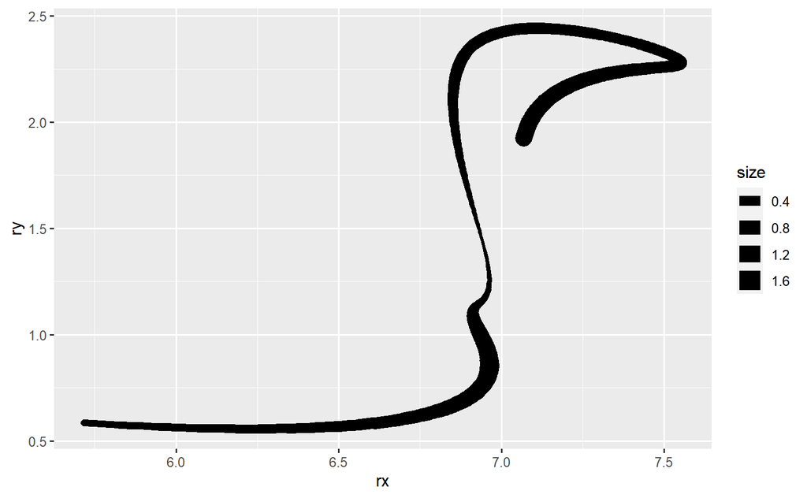

```r
ggplot() +
  geom_bspline2(data = signature,
                aes(x = rx,
                     y = ry,
                     size = size,
                    group = x),
                n = 800,
                lineend = "round")
```

Plot:

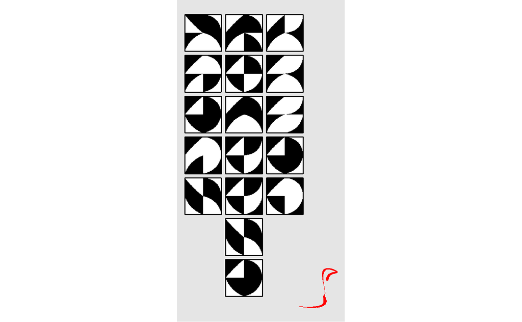

```r
atext_bd |>
  # Dissolve the tiles to obtain a cleaner look for the glyphs
  st_truchet_dissolve() |>
  #mutate(color = as.factor(color)) |>
  filter(color == "1") |>
  ggplot() +
  # Union of the tiles to add a frame to each glyph
  geom_sf(data = atext_bd |>
            st_union(),
          fill = "white",
          color = "black") +
  geom_sf(fill = "black",
          color = NA,
          size = 1) +
  geom_bspline2(data = signature,
                aes(x = rx,
                    y = ry,
                    size = size,
                    group = x),
                color = "red",
                #size = 1,
                n = 800,
                lineend = "round") +
  scale_size(range = c(0, 1.5)) +
  #scale_fill_distiller(direction = 1) +
  theme_void() +
  theme(legend.position = "none",
    plot.background = element_rect(fill = "grey90",
                                   color = NA))

# Save named image
ggsave(glue::glue(here::here(), "/output/asemic-haiku-truchet-{seed}.png"),
       height = 10,
       width = 8,
       units = "cm")
```